# Basi RStudio

Didattica Integrativa - Analisi dei dati in Psicologia dello Sviluppo aa 2025/2026

Author

Matteo Manente

Published

23 March 2026

# Lo Scenario

Immaginiamo di avere un dataset reale raccolto su 85 studenti/esse di scuole superiori.

Abbiamo misurato:

- Età
- Genere
- Reddito della famiglia
- Stress scolastico
- Depressione

**DOMANDA DI RICERCA:** *“Esiste una correlazione tra lo stress scolastico e i sintomi depressivi?”*

# Spoiler: Il punto di arrivo

Non preoccupatevi di capire questo blocco ora, serve solo per mostrarvi cosa sarete in grado di fare con 4 semplici righe di codice alla fine del corso!

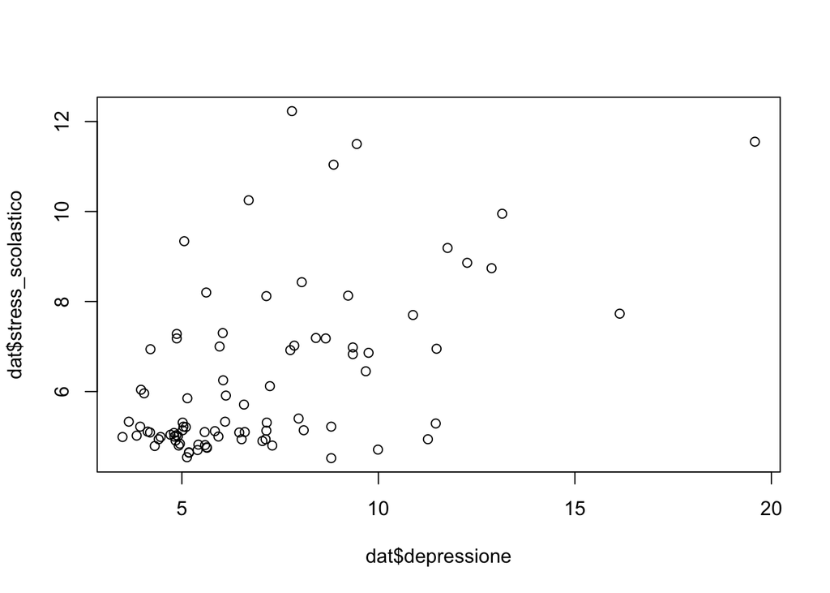

```r
# 1. Diciamo a R di leggere il nostro file dati (importiamo i dati)
dat <- read.csv("dat_scuole.csv")

# 2. Creiamo un grafico a dispersione per visualizzare la relazione
plot(dat$depressione, dat$stress_scolastico)
```

```r
# 3. Chiediamo il valore esatto della correlazione (r di Pearson)
cor(dat$depressione, dat$stress_scolastico)
```

```
[1] 0.5530956
```

```r
# 4. Facciamo il test statistico completo per vedere se è significativa (p-value)
cor.test(dat$depressione, dat$stress_scolastico)
```

```
    Pearson's product-moment correlation

data:  dat$depressione and dat$stress_scolastico
t = 6.0483, df = 83, p-value = 4.036e-08
alternative hypothesis: true correlation is not equal to 0
95 percent confidence interval:
 0.3854020 0.6854234
sample estimates:
      cor
0.5530956
```

**WarningLe “Regole” di R:**

Prima di iniziare, prendiamo familiarità con le leggi fondamentali di RStudio:

1. **I Decimali**: R parla inglese. Si usa il PUNTO `.`, non la virgola `,`! *(es. 3.14)*
2. **Case Sensitive**: R è pignolo e distingue tra maiuscole e minuscole. `Età` è diverso da `età` o `ETA`.
3. **Runnare il codice**: Per far eseguire a R un comando, dovete posizionarvi sulla riga e premere `Ctrl + Enter` (su Windows) o `Cmd + Enter` (su Mac).

# 1. Workspace & Environment

Immaginate la *Working Directory* come la **“Stanza”** in cui state lavorando, e l’*Environment* come la vostra **“Scrivania”**.

```r
# Dove ci troviamo ora nel computer? (Qual è la nostra stanza?)
getwd()
```

```
[1] "/Users/matteomanente/research/learning/courses/teacher/integrativa_pastore_2026/slide_didattica_integrativa_pastore_2026"
```

```r
# Cambiare stanza (Impostare la cartella in cui abbiamo salvato i dati)
# setwd("C:/Percorso/Della/Vostra/Cartella")
```

```r
# Cosa c'è attualmente sulla nostra scrivania? (Lista degli oggetti in memoria)
ls()
```

```
[1] "dat"
```

```r
# Fare pulizia! Buttiamo via tutto per fare ordine
rm(list=ls())
```

### Il Workflow Ideale

Per non perdere mai i vostri dati, seguite sempre questi passaggi:

0. Aprire **Rstudio**
1. Creare un **RProject** - cubo in alto a sinistra (Per dire a R: “Lavoreremo in questa cartella”).
2. Aprire uno Script (`File > New File > R Script` o `Quarto Document`) per scrivere il codice.
3. Caricare eventuali pacchetti con `library()` e scrivere il codice.
4. **Salvataggio**: Quando chiudiamo RStudio, ci chiederà se salvare il workspace (`.RData`).  
   **Meglio rispondere: NO**. Vogliamo salvare solo lo Script (le “istruzioni”), non i risultati temporanei.
   - *Tip: Andate in Tools > Global Options > General > “Save workspace to .RData on exit” = “Never”.*
5. Close Project (in alto a destra)

# 2. R come Calcolatrice

R può fare tutto quello che fa una calcolatrice scientifica.

```r
# Operazioni di base
2 + 2         # somma
```

```
[1] 4
```

```r
10 - 3        # sottrazione
```

```
[1] 7
```

```r
4 * 5         # moltiplicazione
```

```
[1] 20
```

```r
20 / 4        # divisione
```

```
[1] 5
```

```r
2^3           # elevazione a potenza
```

```
[1] 8
```

```r
sqrt(4)       # radice quadrata
```

```
[1] 2
```

```r
abs(-10)      # valore assoluto
```

```
[1] 10
```

```r
# Domanda logica: Cosa restituisce se gli chiedo "5 è maggiore di 3?"
5 > 3         # R ci risponderà: TRUE (Vero)
```

```
[1] TRUE
```

```r
5 < 3         # R ci risponderà: FALSE (Falso)
```

```
[1] FALSE
```

## Applichiamo la matematica ai dati reali

Come calcolare la media dell’età dei nostri 85 partecipanti?

*Assicuratevi di avere il file ‘dat_scuole.csv’ nella stessa cartella del vostro progetto.*

```r
# Importiamo il dataset nel nostro ambiente chiamandolo 'dat'
dat <- read.csv("dat_scuole.csv")

# O in alternativa (se file Excel)
library(readxl)
dat <- read_xlsx("dat_scuole.xlsx")

# Visualizziamolo come fosse un foglio Excel
# View(dat)

# La media: METODO MANUALE (formula: somma dei valori diviso N)
dat$eta           # Il simbolo '$' ci permette di estrarre solo la colonna 'eta'
```

```
 [1] 16 16 19 18 17 18 18 16 14 16 15 17 15 19 17 16 19 15 19 14 19 14 17 16 17
[26] 18 17 15 19 18 19 17 15 14 17 18 19 16 16 17 18 19 18 16 16 14 16 16 17 19
[51] 18 19 18 19 16 16 16 17 19 18 18 16 18 16 15 18 18 16 18 19 14 14 14 15 16
[76] 16 17 16 17 18 17 17 18 14 18
```

```r
sum(dat$eta)      # Sommiamo tutte le 85 età
```

```
[1] 1430
```

```r
length(dat$eta)   # Contiamo quante età ci sono (il nostro 'N')
```

```
[1] 85
```

```r
sum(dat$eta) / length(dat$eta)  # Ecco la nostra media calcolata a mano!
```

```
[1] 16.82353
```

```r
# METODO VELOCE (Usando le funzioni interne di R)
mean(dat$eta)     # Media
```

```
[1] 16.82353
```

```r
var(dat$eta)      # Varianza
```

```
[1] 2.408964
```

```r
sd(dat$eta)       # Deviazione Standard
```

```
[1] 1.552084
```

# 3. Oggetti

In R, se facciamo un calcolo, il risultato appare nella Console e scompare. Per conservarlo sulla nostra “scrivania” dobbiamo metterlo dentro un **OGGETTO** (come fosse una scatola) e attaccarci un’etichetta.

L’operatore di assegnazione è la freccia `<-` *(tasto rapido: Alt + trattino)*.

```r
x <- 5          # Prendo il 5 e lo metto nell'oggetto 'x'
y <- 10 - 3     # Calcolo 10-3 (7) e lo metto nell'oggetto 'y'
x + y           # Ora posso fare calcoli usando direttamente le scatole!
```

```
[1] 12
```

```r
# Salviamo i risultati veri dei nostri dati
eta_media <- mean(dat$eta)
eta_dev_standard <- sd(dat$eta)

# Domanda: Cosa succede se ora scrivo solo 'eta_media'?
eta_media       # R apre la scatola e ci mostra cosa c'è dentro!
```

```
[1] 16.82353
```

```r
# Creiamo un oggetto 'nome' e mettiamoci dentro il nome "Marco"

# Se scriviamo così: nome <- Marco
# Cosa succede?


# Quando vogliamo inserire del TESTO (variabili di tipo 'character'),
# DOBBIAMO USARE LE VIRGOLETTE "".

nome1 <- "Marco"        # Ora funziona! R capisce che è una parola.
```

**NoteTesto vs Oggetti**

Se volete salvare una parola (una variabile *character*), **dovete usare le virgolette `""`**. Se scrivete `nome <- Marco` senza virgolette, R cercherà un oggetto (una scatola) che si chiama Marco, e vi darà errore (`object 'Marco' not found`). La sintassi corretta è: `nome1 <- "Marco"`.

# 4. Vettori

Un **VETTORE** è un oggetto che contiene PIÙ valori dello STESSO TIPO (o tutti numeri, o tutti nomi). La funzione base per creare un vettore è `c()` che sta per *combine*.

```r
# Vettore di testo (character)
nomi <- c("Giulia", "Sofia", "Luca", "Andrea")
nomi
```

```
[1] "Giulia" "Sofia"  "Luca"   "Andrea"
```

```r
# Vettore numerico
num <- c(4, 7, 1009, 5.3)
num
```

```
[1]    4.0    7.0 1009.0    5.3
```

```r
# Possiamo anche estrarre un'intera colonna dal nostro dataset
# e farla diventare un vettore a sé stante:
depressione <- dat$depressione
depressione
```

```
 [1]  5.18  4.20  3.65  4.04  4.95  5.59  7.76  5.62  8.41  4.31  8.80  6.70
[13]  5.93  4.90  3.96 12.26  6.58  7.30  7.16  7.24  4.13  4.86  7.97  8.86
[25]  3.85  7.13  3.94  7.86  4.19  7.15  9.68 16.14  5.10 11.76  5.18  9.23
[37]  6.46  5.96  5.63  9.99  9.45  6.04  6.05  8.66  9.35  5.84  9.35 10.88
[49]  5.13 13.15  3.49  5.58  5.02  5.64 12.88  4.92  6.12  4.41  7.05  8.80
[61]  4.87  7.15  5.04 11.46  4.84  7.80  4.71  4.46  9.75 11.26  6.52  5.40
[73]  5.02  4.80  8.10  5.42  6.60  5.14  5.06  4.87 19.58  4.81 11.48  8.05
[85]  6.10
```

Possiamo anche generare vettori automaticamente per simulare dati. Usiamo la funzione `sample()` per pescare lettere a caso o creare ID numerici:

```r
# La parola 'LETTERS' (tutto maiuscolo) è un oggetto già presente in R
# che contiene tutto l'alfabeto.
LETTERS
```

```
 [1] "A" "B" "C" "D" "E" "F" "G" "H" "I" "J" "K" "L" "M" "N" "O" "P" "Q" "R" "S"
[20] "T" "U" "V" "W" "X" "Y" "Z"
```

```r
# Usiamo la funzione sample() per "pescare" da questo alfabeto a caso.
iniziali <- sample(
  x = LETTERS,           # Da dove peschiamo? (Dalle lettere dell'alfabeto)
  size = 85,             # Quante estrazioni facciamo? (85, come i nostri studenti)
  replace = TRUE         # Estrazione CON re-inserimento (replace = TRUE).
  # È essenziale: essendoci solo 26 lettere e 85 studenti,
  # le lettere DEVONO potersi ripetere!
)

iniziali                 # Ecco il nostro vettore di 85 iniziali!
```

```
 [1] "Q" "D" "S" "M" "B" "N" "Q" "G" "X" "K" "S" "H" "A" "B" "M" "L" "A" "R" "R"
[20] "T" "X" "K" "Q" "K" "M" "T" "F" "G" "H" "I" "D" "Z" "F" "W" "E" "P" "F" "W"
[39] "S" "O" "F" "K" "C" "O" "G" "N" "U" "F" "O" "C" "Q" "Q" "C" "J" "J" "T" "F"
[58] "M" "Q" "W" "I" "X" "U" "Z" "C" "J" "H" "I" "X" "V" "N" "X" "T" "L" "J" "Y"
[77] "K" "Z" "T" "M" "V" "D" "D" "T" "F"
```

```r
# Ora vogliamo creare un ID (codice identificativo) numerico e segreto
# a 3 cifre per ogni partecipante.

id_random <- sample(
  x = 100:999,           # Popolazione: tutti i numeri da 100 a 999
  size = 85,             # Quanti ID ci servono? 85
  replace = FALSE        # Estrazione SENZA re-inserimento (replace = FALSE).
  # Molto importante: ogni studente deve avere un ID UNICO.
  # Vietati i doppioni!
)

id_random
```

```
 [1] 643 160 145 950 977 277 637 809 819 898 410 731 512 195 995 484 666 478 397
[20] 979 374 429 635 486 351 469 720 137 192 464 803 970 232 703 471 533 765 985
[39] 709 960 716 724 353 461 281 231 186 318 479 725 459 173 467 657 910 531 154
[58] 807 937 692 857 674 418 886 600 448 571 621 279 941 258 662 660 193 683 114
[77] 860 167 368 352 365 935 208 327 345
```

# 5. Matrici

Mentre un vettore ha una sola dimensione, una **MATRICE** è una tabella a due dimensioni (righe e colonne).

**ATTENZIONE:** le matrici possono contenere un SOLO TIPO di dato. Se mescoliamo numeri e testo, R trasformerà tutto in testo!

```r
# 1. Prepariamo dei dati finti (4 studenti x 3 variabili)
valori_studenti <- c(16, 16, 19, 18,        # Età
                     4.64, 6.94, 5.33, 5.96,# Stress
                     5.18, 4.20, 3.65, 4.04)# Depressione

valori_studenti # R ce li mostra come una singola sequenza di 12 numeri
```

```
 [1] 16.00 16.00 19.00 18.00  4.64  6.94  5.33  5.96  5.18  4.20  3.65  4.04
```

```r
# 2. Trasformiamo il vettore in una matrice
# Usiamo la funzione matrix() dicendo a R quante righe e colonne vogliamo
matrice_dati <- matrix(valori_studenti, nrow = 4, ncol = 3)

matrice_dati
```

```
     [,1] [,2] [,3]
[1,]   16 4.64 5.18
[2,]   16 6.94 4.20
[3,]   19 5.33 3.65
[4,]   18 5.96 4.04
```

```r
# Cosa è successo? R ha preso i 12 numeri e ha riempito la tabella
# "dall'alto verso il basso", colonna per colonna.
# Colonna 1 = Età, Colonna 2 = Stress, Colonna 3 = Depressione.

# Se volessimo riempire la matrice riga per riga (da sinistra a destra),
# dovremmo usare l'argomento 'byrow = TRUE':
matrice_riga <- matrix(valori_studenti, nrow = 4, ncol = 3, byrow = TRUE)
matrice_riga # Nota come i dati ora sono posizionati diversamente!
```

```
      [,1]  [,2]  [,3]
[1,] 16.00 16.00 19.00
[2,] 18.00  4.64  6.94
[3,]  5.33  5.96  5.18
[4,]  4.20  3.65  4.04
```

```r
# 3. Assegniamo nomi a righe e colonne per orientarci
colnames(matrice_dati) <- c("Eta", "Stress", "Depressione")
rownames(matrice_dati) <- c("Studente_1", "Studente_2", "Studente_3", "Studente_4")

matrice_dati
```

```
           Eta Stress Depressione
Studente_1  16   4.64        5.18
Studente_2  16   6.94        4.20
Studente_3  19   5.33        3.65
Studente_4  18   5.96        4.04
```

### Navigare e modificare le matrici

In R, le parentesi quadre `[ ]` servono per estrarre. La regola è sempre: `[RIGA , COLONNA]`.

```r
# Estrazione
matrice_dati[3, 2]     # Stress (colonna 2) dello Studente 3 (riga 3)
```

```
[1] 5.33
```

```r
matrice_dati[2, ]      # Profilo completo dello Studente 2 (tutta la riga)
```

```
        Eta      Stress Depressione
      16.00        6.94        4.20
```

```r
matrice_dati[ , 3]     # Tutti i punteggi di Depressione (tutta la colonna)
```

```
Studente_1 Studente_2 Studente_3 Studente_4
      5.18       4.20       3.65       4.04
```

```r
# Modifica (Correggiamo l'età dello Studente 4)
matrice_dati[4, 1] <- 19

# Eliminazione (Il segno '-' esclude)
matrice_dati[-1, ]     # Matrice senza lo Studente 1
```

```
           Eta Stress Depressione
Studente_2  16   6.94        4.20
Studente_3  19   5.33        3.65
Studente_4  19   5.96        4.04
```

### Unire matrici e vettori

```r
# Arrivano 2 NUOVI STUDENTI (Unione per RIGA - rbind)
nuovi_studenti <- matrix(c(17, 5.20, 4.10,
                           18, 6.80, 5.50),
                         nrow = 2, ncol = 3, byrow = TRUE)

colnames(nuovi_studenti) <- c("Eta", "Stress", "Depressione")

matrice_piu_soggetti <- rbind(matrice_dati, nuovi_studenti)

matrice_piu_soggetti
```

```
           Eta Stress Depressione
Studente_1  16   4.64        5.18
Studente_2  16   6.94        4.20
Studente_3  19   5.33        3.65
Studente_4  19   5.96        4.04
            17   5.20        4.10
            18   6.80        5.50
```

```r
# Aggiungiamo 2 NUOVE VARIABILI (Unione per COLONNA - cbind)
nuove_variabili <- matrix(c(6.5, 7.2,
                            4.1, 8.5,
                            5.8, 6.0,
                            7.9, 4.5),
                          nrow = 4, ncol = 2, byrow = TRUE)
colnames(nuove_variabili) <- c("Ansia", "Autostima")

matrice_piu_variabili <- cbind(matrice_dati, nuove_variabili)

matrice_piu_variabili
```

```
           Eta Stress Depressione Ansia Autostima
Studente_1  16   4.64        5.18   6.5       7.2
Studente_2  16   6.94        4.20   4.1       8.5
Studente_3  19   5.33        3.65   5.8       6.0
Studente_4  19   5.96        4.04   7.9       4.5
```

# 6. Data Frame

Il **Data Frame** è la classica tabella a cui siamo abituati in Excel. La grande differenza rispetto alle matrici è che qui **ogni colonna può contenere un tipo di dato diverso!**

```r
# Creazione di un piccolo Data Frame misto
df_studenti <- data.frame(
  id = c(1, 2, 3, 4),
  genere = c("F", "F", "M", "M"),
  eta = c(16, 16, 19, 18),
  stress = c(4.64, 6.94, 5.33, 5.96)
)
df_studenti
```

```
  id genere eta stress
1  1      F  16   4.64
2  2      F  16   6.94
3  3      M  19   5.33
4  4      M  18   5.96
```

### Esplorazione e Filtri

Oltre a usare `[RIGA, COLONNA]`, nei Data Frame il nostro migliore amico è il simbolo **`$`**, che ci permette di richiamare le variabili direttamente per nome.

```r
# Selezione elementi

# Regola base: funziona esattamente come le matrici con le parentesi quadre [RIGA, COLONNA]
df_studenti[2, 4]  # Stress (colonna 4) dello studente 2 (riga 2)
```

```
[1] 6.94
```

```r
df_studenti[3, ]   # Tutti i dati dello studente 3
```

```
  id genere eta stress
3  3      M  19   5.33
```

```r
df_studenti[ , 3]  # L'età di tutti gli studenti
```

```
[1] 16 16 19 18
```

```r
# IL SIMBOLO DEL DOLLARO ($)
# Nei data frame, possiamo chiamare una colonna direttamente per NOME usando '$'.
# È molto più sicuro e intuitivo dei numeri di colonna.
df_studenti$eta      # Estrae tutta la colonna 'eta'
```

```
[1] 16 16 19 18
```

```r
df_studenti$stress   # Estrae tutta la colonna 'stress'
```

```
[1] 4.64 6.94 5.33 5.96
```

```r
# Selezione con operatori logici (<, >, ==)

# Possiamo usare i fattori logici per "filtrare" i nostri partecipanti.
# Quali studenti sono MAGGIORENNI (hanno un'età maggiore o uguale a 18)?
df_studenti$eta >= 18
```

```
[1] FALSE FALSE  TRUE  TRUE
```

```r
# R ci risponde con TRUE o FALSE. Se inseriamo questa condizione nelle RIGHE,
# R ci estrarrà solo i partecipanti per cui la condizione è TRUE:
studenti_maggiorenni <- df_studenti[df_studenti$eta >= 18, ]
studenti_maggiorenni
```

```
  id genere eta stress
3  3      M  19   5.33
4  4      M  18   5.96
```

```r
# Estraiamo solo le femmine (nota il DOPPIO UGUALE '==' per dire "è esattamente uguale a")
solo_femmine <- df_studenti[df_studenti$genere == "F", ]
solo_femmine
```

```
  id genere eta stress
1  1      F  16   4.64
2  2      F  16   6.94
```

```r
# Modificare elementi

# Usiamo il dollaro e l'indice per correggere un errore.
# Ops, l'età dello studente 1 non è 16, ma 17!
df_studenti$eta[1] <- 17
df_studenti
```

```
  id genere eta stress
1  1      F  17   4.64
2  2      F  16   6.94
3  3      M  19   5.33
4  4      M  18   5.96
```

```r
# Vogliamo trasformare tutti i punteggi di stress aggiungendo 1 punto?
df_studenti$stress <- df_studenti$stress + 1
df_studenti
```

```
  id genere eta stress
1  1      F  17   5.64
2  2      F  16   7.94
3  3      M  19   6.33
4  4      M  18   6.96
```

```r
# Eliminare righe e colonne

# Per eliminare una RIGA si usa il segno '-' come nelle matrici
df_senza_sogg2 <- df_studenti[-2, ]
df_senza_sogg2
```

```
  id genere eta stress
1  1      F  17   5.64
3  3      M  19   6.33
4  4      M  18   6.96
```

```r
# Per eliminare una COLONNA, il trucco più usato in R è assegnarle il valore 'NULL' (vuoto)
df_studenti$id <- NULL
df_studenti  # La colonna 'id' è sparita!
```

```
  genere eta stress
1      F  17   5.64
2      F  16   7.94
3      M  19   6.33
4      M  18   6.96
```

```r
# Unire Data Frame

# SCENARIO: Arriva un nuovo studente (Riga)
nuovo_studente <- data.frame(
  genere = "F",
  eta = 17,
  stress = 5.00
)

# rbind (Row Bind) - Uniamo sotto.
# ATTENZIONE: i nomi delle colonne devono essere IDENTICI!
df_aggiornato <- rbind(df_studenti, nuovo_studente)
df_aggiornato
```

```
  genere eta stress
1      F  17   5.64
2      F  16   7.94
3      M  19   6.33
4      M  18   6.96
5      F  17   5.00
```

```r
# SCENARIO: Aggiungiamo il punteggio di "Depressione" a tutti (Colonna)
# Abbiamo 5 studenti ora, quindi servono 5 punteggi
punteggi_depressione <- c(3.5, 4.2, 2.1, 5.5, 4.0)

# cbind (Column Bind) - Uniamo a destra.
# In alternativa, si poteva fare anche: df_aggiornato$depressione <- punteggi_depressione
df_completo <- cbind(df_aggiornato, depressione = punteggi_depressione)
df_completo
```

```
  genere eta stress depressione
1      F  17   5.64         3.5
2      F  16   7.94         4.2
3      M  19   6.33         2.1
4      M  18   6.96         5.5
5      F  17   5.00         4.0
```

```r
# Funzioni utili
nrow(df_studenti)      # Numero di righe (quanti partecipanti abbiamo?)
```

```
[1] 4
```

```r
ncol(df_studenti)      # Numero di colonne (quante variabili?)
```

```
[1] 3
```

```r
rownames(df_studenti)  # Nomi delle righe (di default sono numeri progressivi)
```

```
[1] "1" "2" "3" "4"
```

```r
colnames(df_studenti)  # Nomi delle colonne (le nostre variabili)
```

```
[1] "genere" "eta"    "stress"
```

```r
# Le 4 funzioni "salva-vita" per esplorare dataset grandi:
head(df_studenti, 2)   # Mostra solo le prime 2 righe (la "testa" dei dati)
```

```
  genere eta stress
1      F  17   5.64
2      F  16   7.94
```

```r
tail(df_studenti, 2)   # Mostra solo le ultime 2 righe (la "coda")
```

```
  genere eta stress
3      M  19   6.33
4      M  18   6.96
```

```r
str(df_studenti)       # Mostra la STRUTTURA: ci dice il tipo di dato di ogni colonna
```

```
'data.frame':   4 obs. of  3 variables:
 $ genere: chr  "F" "F" "M" "M"
 $ eta   : num  17 16 19 18
 $ stress: num  5.64 7.94 6.33 6.96
```

```r
summary(df_studenti)   # Ci fa un RIASSUNTO statistico immediato (min, max, media, ecc.)
```

```
    genere               eta            stress
 Length:4           Min.   :16.00   Min.   :5.640
 Class :character   1st Qu.:16.75   1st Qu.:6.157
 Mode  :character   Median :17.50   Median :6.645
                    Mean   :17.50   Mean   :6.718
                    3rd Qu.:18.25   3rd Qu.:7.205
                    Max.   :19.00   Max.   :7.940
```

# 7. Statistica Descrittiva

*Let’s look at the data!* Esploriamo il nostro dataset `dat` che abbiamo importato all’inizio.

```r
# Sintesi generale del dataset (Min, Max, Medie, Quartili)
summary(dat)
```

```
       id        genere               eta        reddito_famiglia
 Min.   : 1   Length:85          Min.   :14.00   Length:85
 1st Qu.:22   Class :character   1st Qu.:16.00   Class :character
 Median :43   Mode  :character   Median :17.00   Mode  :character
 Mean   :43                      Mean   :16.82
 3rd Qu.:64                      3rd Qu.:18.00
 Max.   :85                      Max.   :19.00
 stress_scolastico  depressione
 Min.   : 4.520    Min.   : 3.490
 1st Qu.: 4.990    1st Qu.: 4.950
 Median : 5.290    Median : 6.050
 Mean   : 6.242    Mean   : 7.008
 3rd Qu.: 7.020    3rd Qu.: 8.410
 Max.   :12.230    Max.   :19.580
```

```r
# Variabilità (Deviazione Standard)
sd(dat$stress_scolastico)
```

```
[1] 1.833474
```

```r
sd(dat$depressione)
```

```
[1] 2.907523
```

```r
# Frequenze Assolute (Variabili Categoriali)
table(dat$genere)
```

```
 F  M
41 44
```

```r
table(dat$reddito_famiglia)
```

```
 Alto Basso Medio
   22    21    42
```

```r
# Frequenze Relative Percentuali
prop.table(table(dat$genere)) * 100
```

```
       F        M
48.23529 51.76471
```

# 8. Visualizzazione dei Dati

La scelta del grafico dipende dalla natura della variabile che stiamo analizzando.

### 1. Variabili Categoriali (Grafico a Barre)

Ricordate: `barplot()` ha bisogno della TABELLA delle frequenze, non della colonna grezza!

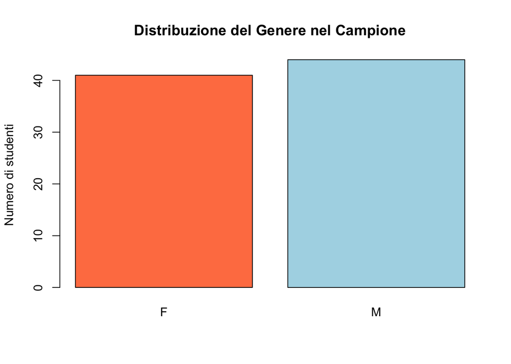

```r
barplot(
  table(dat$genere),
  main = "Distribuzione del Genere nel Campione",
  ylab = "Numero di studenti",
  col = c("coral", "lightblue")
)
```

### 2. Variabili Continue (Istogramma)

Ci mostra la forma della distribuzione (es. curva a campana).

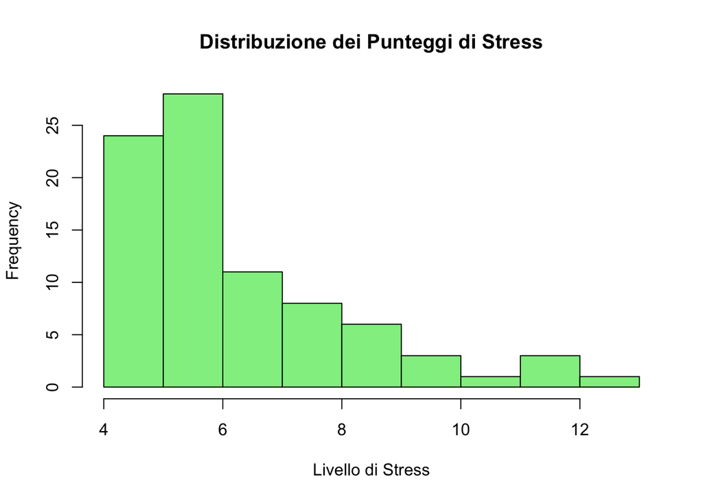

```r
hist(
  dat$stress_scolastico,
  main = "Distribuzione dei Punteggi di Stress",
  xlab = "Livello di Stress",
  col = "lightgreen"
)
```

### 3. Due Variabili Continue (Scatterplot)

Rispondiamo alla domanda di ricerca: c’è relazione tra stress e depressione?

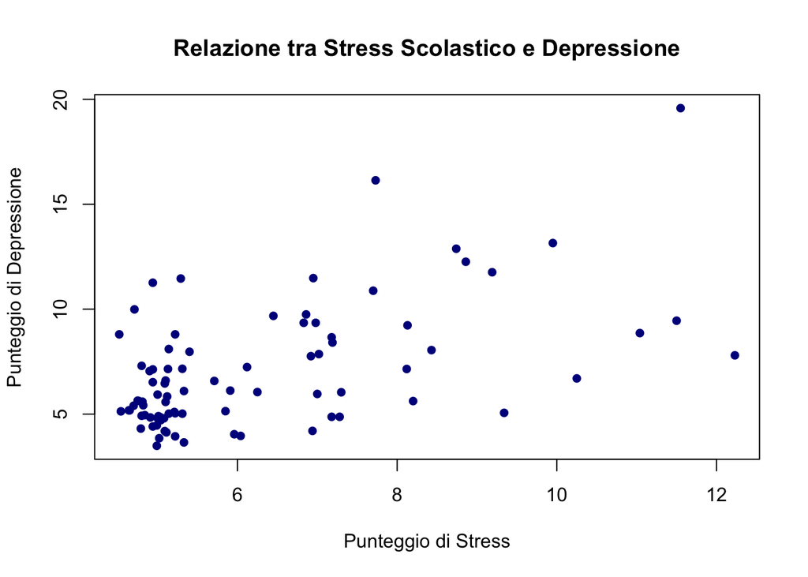

```r
plot(
  x = dat$stress_scolastico,
  y = dat$depressione,
  main = "Relazione tra Stress Scolastico e Depressione",
  xlab = "Punteggio di Stress",
  ylab = "Punteggio di Depressione",
  pch = 16,
  col = "darkblue"
)
```

### 4. Confrontare Gruppi (Boxplot)

La sintassi di R usa la tilde **`~`** che si legge *“in funzione di”*.

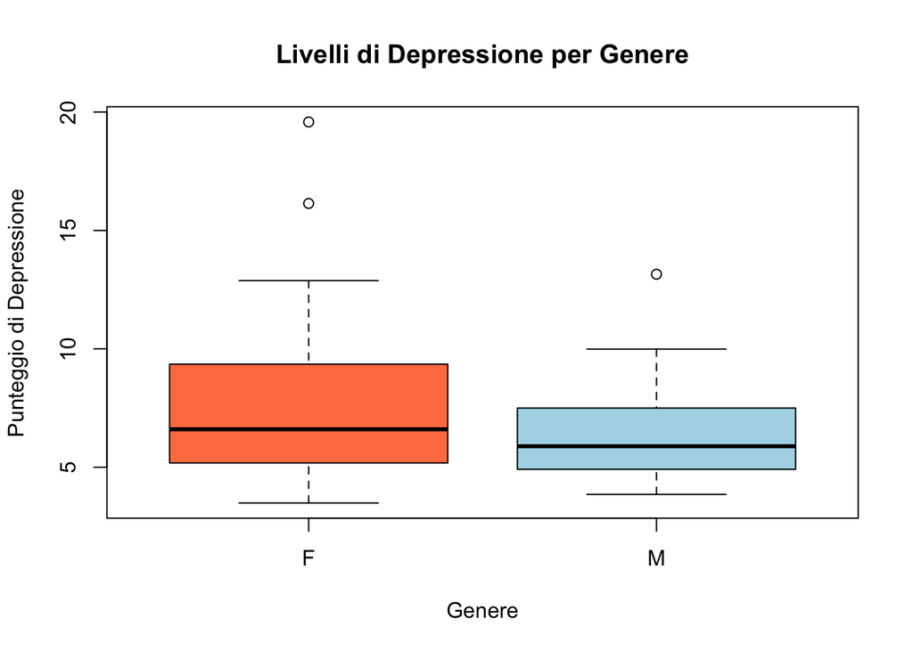

```r
boxplot(
  formula = dat$depressione ~ dat$genere,
  main = "Livelli di Depressione per Genere",
  ylab = "Punteggio di Depressione",
  xlab = "Genere",
  col = c("coral", "lightblue")
)
```